# Documentation riverconn for CCM2

Viola Wittekind

2023-01-05

## Tutorial to create igraph objects from CCM2 data and calculate fragmentation indices with riverconn

# Introduction

This document is a guide to create an igraph object from CCM2 geodata for use with the riverconn package. The pre-processing is adapted for CCM2 data which has a higher resolution than the ECRINS database on which the riverconn package was developed. Due to the directionallity information contained in CCM2 the pre-processing can be accelerated. Other changes include the inclusion of barriers and the creation of the igraph object.  
This guide is based on the [riverconn_tutorial](https://damianobaldan.github.io/riverconn_tutorial/) of Damiano Baldan.

# 1.1 Packages needed

Make sure those libraries are installed, updated, and loaded.

```r
library("rgdal")
library("tidyverse")
library("sf")
library("raster")
library("ggspatial")
library("viridis")
library("igraph")
library("riverconn")
library("elevatr")
library("gridExtra")
#library("ggnetwork") # not needed rigth now
library("lwgeom")
library("gridExtra")
library("RANN")
library("ggpubr")
library("cowplot")
library("data.table")
library("rgeos")
library("foreach")
library("doParallel")
```

# Data

For the river network the geodatabase [CCM2](https://ccm.jrc.ec.europa.eu/php/index.php?action=view&id=24) is used. The CCM2 data is divided in Data Windows. The relevant layers of the databases for this guide are “SEAOUTLETS” (basin_file), “RIVERSEGMENTS”(river_file) and “RIVERNODES” (confluences).

Information of barriers in this tutorial are taken from [AMBER](https://www.nature.com/articles/s41586-020-3005-2).

By using ‘sf’ objects and their ability to link geographic information to the data.frame structure, it is easy to edit the rivernetwork while keeping the geometry.

## Data import

Set the path to the location of the database and dbname to the name of the database!

For the import of the barriers set amberpath to the path of the csv file with the barrier information.

```r
## Segments and Confluences
# choose data window (see CCM2_data_windows.JPG)
window <- "2004"
# set dbname and path (location of data on your local computer)
dbname <- paste0("LAEA_W",window,".gdb") #"WGS84_W",window,".gdb"
path <- paste0("/home/vicky/Documents/LAEA/")

file.exists(path)#Check that you have chosen the right path
```

```
## [1] TRUE
```

```r
#ogrListLayers(paste0(path,dbname))#lists the Layers of the db
options(knitr.duplicate.label = "allow")

basin_file <- st_read(paste0(path,dbname), layer = "SEAOUTLETS" )
## Reading layer `SEAOUTLETS' from data source
##   `/home/vicky/Documents/LAEA/LAEA_W2004.gdb' using driver `OpenFileGDB'
## Simple feature collection with 2343 features and 16 fields
## Geometry type: MULTIPOLYGON
## Dimension:     XY
## Bounding box:  xmin: 2636000 ymin: 1581200 xmax: 3818700 ymax: 2468000
## Projected CRS: ETRS89-extended / LAEA Europe
river_file  <- st_read(paste0(path,dbname), layer = "RIVERSEGMENTS" )
## Reading layer `RIVERSEGMENTS' from data source
##   `/home/vicky/Documents/LAEA/LAEA_W2004.gdb' using driver `OpenFileGDB'
## Simple feature collection with 95424 features and 22 fields
## Geometry type: MULTILINESTRING
## Dimension:     XY
## Bounding box:  xmin: 2637950 ymin: 1582250 xmax: 3815750 ymax: 2464050
## Projected CRS: ETRS89-extended / LAEA Europe
confluences <- st_read(paste0(path,dbname), layer = "RIVERNODES" )
## Reading layer `RIVERNODES' from data source
##   `/home/vicky/Documents/LAEA/LAEA_W2004.gdb' using driver `OpenFileGDB'
## Simple feature collection with 96378 features and 9 fields
## Geometry type: POINT
## Dimension:     XY
## Bounding box:  xmin: 2637950 ymin: 1582250 xmax: 3815750 ymax: 2464050
## Projected CRS: ETRS89-extended / LAEA Europe

## Barriers
#path of the Amber barriers on your local computer
amberpath <- "/home/vicky/Documents/AMBER/atlas.csv"

amber <- fread(amberpath)
```

# Chose River Basin

To choose the River Basin you can either look for a name of a river (in this example river “Tajo”) or directly use the WSO_ID as an unique identifier of the Sea-outlet.

```r
basin_df <- basin_file %>% as.data.frame()
#unique(basin_df$NAME) #returns the names of the rivers present in the database

basinname <- "Tajo"
basin_id <- unique(na.omit(basin_df[basin_df$NAME == basinname,]$WSO_ID)) #WSO_ID River Basin ID

#Basin
basn <- basin_file[basin_file$WSO_ID== basin_id, ] #SEAOUTLETS
#Segments
riv <- river_file[river_file$WSO_ID== basin_id,] #RIVERSEGMENTS
#Nodes
nodes <- confluences[confluences$WSO_ID== basin_id, ] #RIVERNODES
```

The projections of the sf objects have to match.

```r
#Match crs
dam_in <- st_as_sf(amber, coords = c("Longitude_WGS84","Latitude_WGS84"))
st_crs(dam_in) <- "+proj=longlat +datum=WGS84"
#Basin
shape_basin <- st_transform(basn,st_crs(dam_in))
#Segments
shape_river <- st_transform(riv,st_crs(dam_in))
#Confluences
river_joins <- st_transform(nodes,st_crs(dam_in))#for elevation at node compare with segments!
```

# Subset dams

The selection of the dams to include in the network is at this point of the process not solved. Further work to this topic is in progress.

A first subset of the barriers of the Amber dataset is created using the polygon of the basinarea (with a buffer of 1 m).

```r
dam <- st_intersection(dam_in, st_buffer(shape_basin,1))
```

# Functions to support data processing

The functions for pre-processing have been adapted and must be loaded in the global environment. Functions in global environment: dam_snap_ccm, dam_include, edges_list.R

```r
#path of functions on your global computer
source("/home/vicky/github/riverconnCCM2/functions/dam_snap_ccm.R")
source("/home/vicky/github/riverconnCCM2/functions/dam_include.R")
source("/home/vicky/github/riverconnCCM2/functions/edges_list.R")
```

# River shapefile preprocessing

The attributes of the river segments on which the riverconn package is based (ECRINS) have different names to the CCM2 database.

The number of accumulated cells (UP_CELLS in ECRINS), a proxy of the upstream catchment area, is used for the calculation of the index for each barrier. The equivalent attribute in CCM2 is CONT_PIXELS (Area upstream the From Node drained by the river segment in 100x100 grid cells).

```r
#rename attributes
shape_river$UP_CELLS = shape_river$CONT_PIXELS
shape_river$alt = shape_river$ALT_GRADIENT
st_geometry(shape_river) <- "geometry"
```

As a next step transform the object of class ‘sf’ with ‘MULTILINESTRING’ geometry into an object of class ‘sf’ containing multiple ‘LINESTRING’ geometries.

```r
shape_river_simple <- shape_river %>%
  st_as_sf %>%
  st_union()


shape_river_line <- shape_river %>% st_cast(.,"LINESTRING" ) %>%
  mutate(EdgeID = as.character(1:nrow(.)))  ##id = WSO1_ID  ##?
```

# Dams pre-processing

The locations of the barriers in the AMBER dataset have errors, and the CCM2 database is missing some river segments. In order to include the dams in the network, the locations of the barriers must overlap with the segments. This problem has not yet been solved satisfactorily.

Nevertheless the snapping function of riverconn was adapted for further development.

In addition, since snapping can take a long time for large networks with multiple dams, an instruction for parallelizing the computation is presented here.

The function dam_snap_ccm is used to snap the barrier points to the river network based on a tolerance threshold (default 10). The function changes the location of the points in distance of the threshold to overlap with the river network.

To parallelise the snapping change libPath to the path of your R library and change ‘funpath’ to the directory of the function ‘dam_snap_ccm’.

```r
x <- dam %>% mutate(id = GUID) %>% dplyr::select(id)

#setup parallel back-end to use many processors
cores=detectCores()
#print(cores)
cl <- makeCluster(cores[1]-1) #not to overload your computer
registerDoParallel(cl)

# Loop
#change to your R lib location and change to location of function
#.libPaths() #find lib path
clusterEvalQ(cl, .libPaths("/home/vicky/R/x86_64-pc-linux-gnu-library/4.2" )) #Change  here your R library path
## [[1]]
## [1] "/home/vicky/R/x86_64-pc-linux-gnu-library/4.2"
## [2] "/usr/local/lib/R/site-library"
## [3] "/usr/lib/R/site-library"
## [4] "/usr/lib/R/library"
##
## [[2]]
## [1] "/home/vicky/R/x86_64-pc-linux-gnu-library/4.2"
## [2] "/usr/local/lib/R/site-library"
## [3] "/usr/lib/R/site-library"
## [4] "/usr/lib/R/library"
##
## [[3]]
## [1] "/home/vicky/R/x86_64-pc-linux-gnu-library/4.2"
## [2] "/usr/local/lib/R/site-library"
## [3] "/usr/lib/R/site-library"
## [4] "/usr/lib/R/library"
##
## [[4]]
## [1] "/home/vicky/R/x86_64-pc-linux-gnu-library/4.2"
## [2] "/usr/local/lib/R/site-library"
## [3] "/usr/lib/R/site-library"
## [4] "/usr/lib/R/library"
##
## [[5]]
## [1] "/home/vicky/R/x86_64-pc-linux-gnu-library/4.2"
## [2] "/usr/local/lib/R/site-library"
## [3] "/usr/lib/R/site-library"
## [4] "/usr/lib/R/library"
##
## [[6]]
## [1] "/home/vicky/R/x86_64-pc-linux-gnu-library/4.2"
## [2] "/usr/local/lib/R/site-library"
## [3] "/usr/lib/R/site-library"
## [4] "/usr/lib/R/library"
##
## [[7]]
## [1] "/home/vicky/R/x86_64-pc-linux-gnu-library/4.2"
## [2] "/usr/local/lib/R/site-library"
## [3] "/usr/lib/R/site-library"
## [4] "/usr/lib/R/library"

funpat <- "/home/vicky/github/riverconnCCM2/functions/" #path of function to run parallel
#dir.exists(funpat)

output <- foreach(i=1:nrow(x), .combine = rbind,
                  .packages= c('dplyr', 'sf')) %dopar% {
  source(paste0(funpat,"dam_snap_ccm.R")) # That is the main point. Source your Function File here.
  temp <- dam_snap_ccm(x[i,],shape_river_line) # use your custom function after sourcing
  temp
}

stopCluster(cl)

dams_snapped <- output
```

Barriers that overlap with the river network sf are taken into account. If two dams are snapped to the same geographical position, duplicates are removed. . Passability values are assigned to the resulting snapped points. Uniform (not dam-dependent) passabilities were assigned: 0.8 for downstream passability, and 0.1 for upstream passability. An id is assigned to each of the geographic points.

```r
# Retain dams that were snapped
dams_snapped_reduced <-
  dams_snapped[st_contains(shape_river_simple %>% st_sf(), dams_snapped, prepared = FALSE)[[1]],]

##dobblesnap
dams_snapped_reduced_joined <- dams_snapped_reduced %>%
  mutate(cluster =
           st_equals(dams_snapped_reduced, dams_snapped_reduced) %>%
           sapply(., FUN = function(x) paste0(x, collapse = "_"))) %>%
  group_by(cluster) %>%
  slice(1) %>%
  ungroup() %>%
  mutate(id_dam = as.character(1:nrow(.)), pass_u = 0.1, pass_d = 0.8) %>%
  as.data.frame %>%  st_as_sf()
```

Finally the barriers and confluences (river_joins) will be combined in an object.

```r
# Create junction point shapefile
network_links <- rbind(
  dams_snapped_reduced_joined %>%
    mutate(type = "dam", id_barrier = id_dam) %>%
    dplyr::select(type, id_barrier, pass_u, pass_d),
  river_joins %>%
    dplyr::select(ID) %>%
    mutate(pass_u = NA, pass_d = NA, type = "joint") %>%
    rename(id_barrier = ID, geometry = SHAPE)) %>% ##enter here name of geometry column
  mutate(id_links = 1:nrow(.))
```

A plot can reveal if the process was successful.

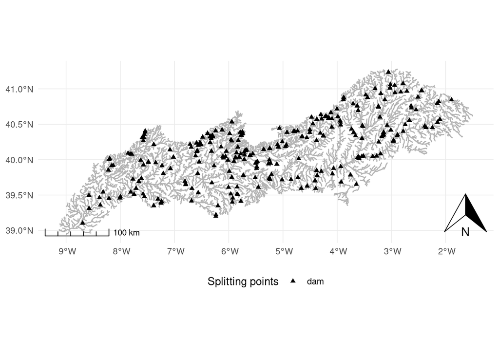

```r
ggplot() +
  coord_fixed() +
  ggspatial::layer_spatial(shape_river_line, color = "gray70")+
  ggspatial::layer_spatial(network_links, aes(shape = type))+
  scale_shape_manual(name = "Splitting points", values=c("dam" =17))+ #,"joint" = 23
  theme_minimal() +
  theme(legend.position = "bottom")+
  ggspatial::annotation_north_arrow(location = "br")+
  ggspatial::annotation_scale(location = "bl", style = "ticks")
```

# `igraph` creation

To include the barriers in the network function ‘dam_include’ creates new segments if a barrier overlaps a segment. The old segment before the inclusion of the barrier will be removed and the new segments are provided with new unique identifiers (Edge_ID).

```r
river_net_sliced <- dam_include(network_links, shape_river_line)
```

Plotting can show weird behaviors of the join operation.

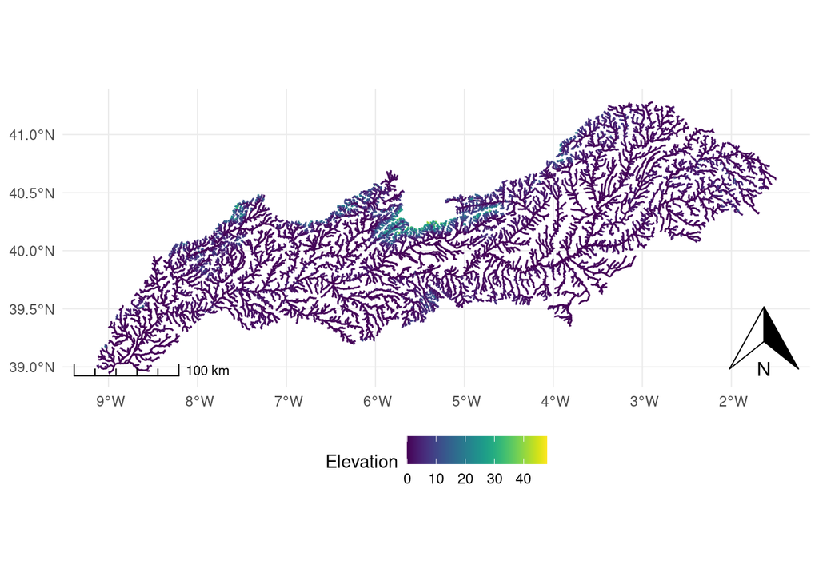

```r
ggplot() +
  coord_fixed() +
  ggspatial::layer_spatial(river_net_sliced, aes(color = alt))+
  scale_color_viridis(name = "Elevation")+
  theme_minimal() +
  theme(legend.position = "bottom")+
  ggspatial::annotation_north_arrow(location = "br")+
  ggspatial::annotation_scale(location = "bl", style = "ticks")
```

To calculate longitudinal river network connectivity with a graph based approach, the river segments are considered as nodes (vertices) and the connections in between, the barriers and confluences, as the edges of the graph network. The function ‘edges_list’ creates a dataframe of the edges.

```r
edgedf <-edges_list(network_links,river_net_sliced)

vertices <- river_net_sliced %>%
  st_drop_geometry %>%
  rename(name = EdgeID) %>%
  mutate(across(c(everything()), as.character))  %>% #, -geom
  mutate(length = as.numeric(SHAPE_Length), alt = as.numeric(alt)) %>% dplyr::select(name, everything())%>%
  mutate(Conname = as.character(1:nrow(.)))  #as.character

river_graph <- graph_from_data_frame(
  d = edgedf,
  directed = TRUE,
  v = vertices)
```

`river_graph` is an object of class `igraph` that keeps the attributes present in the shapefile and in the junction.

```r
# Check igraph object
river_graph
## IGRAPH d9ac46d DN-- 10262 10261 --
## + attr: name (v/c), WSO1_ID (v/c), WSO_ID (v/c), RVR_ID (v/c), FROMNODE
## | (v/c), TONODE (v/c), STRAHLER (v/c), PFAFSTETTER (v/c), NEXTDOWNID
## | (v/c), LONGPATH (v/c), MAINDRAIN_CLASS (v/c), MAINDRAIN_ID (v/c),
## | LENGTH (v/c), CUM_LEN (v/c), PIXELS_100M (v/c), CATCHMENT_AREA (v/c),
## | CONT_PIXELS (v/c), DRAIN_KM2 (v/c), ALT_GRADIENT (v/c), BURNED (v/c),
## | CONFIDENCE (v/c), WINDOW (v/c), SHAPE_Length (v/c), UP_CELLS (v/c),
## | alt (v/n), length (v/n), Conname (v/c), type (e/c), id_links (e/n),
## | id_barrier (e/c), pass_u (e/n), pass_d (e/n)
## + edges from d9ac46d (vertex names):
## [1] 7387_1->7387_2 8249_1->8249_2 5374_1->5374_2 5982_1->5982_2 5949_1->5949_2
## + ... omitted several edges
# check river_graph edges
igraph::get.edge.attribute(river_graph) %>% names
```

```
## [1] "type"       "id_links"   "id_barrier" "pass_u"     "pass_d"
```

```r
# check river_graph vertices
igraph::get.vertex.attribute(river_graph) %>% names
```

```
##  [1] "name"            "WSO1_ID"         "WSO_ID"          "RVR_ID"
##  [5] "FROMNODE"        "TONODE"          "STRAHLER"        "PFAFSTETTER"
##  [9] "NEXTDOWNID"      "LONGPATH"        "MAINDRAIN_CLASS" "MAINDRAIN_ID"
## [13] "LENGTH"          "CUM_LEN"         "PIXELS_100M"     "CATCHMENT_AREA"
## [17] "CONT_PIXELS"     "DRAIN_KM2"       "ALT_GRADIENT"    "BURNED"
## [21] "CONFIDENCE"      "WINDOW"          "SHAPE_Length"    "UP_CELLS"
## [25] "alt"             "length"          "Conname"
```

# Editing the `igraph` object

The edges and vertices attributes can be further edited.The ‘length’ vertices attributes is expressed in meters. The value is changed to tens of kilometers for the following calculations. Some fields with habitat suitability information will be added. Two different habitat curves are implemented to link elevation and habitat preference, one for high-altitude organisms and one for low-altitude organisms. Relative reach-specific habitat suitability indices (HSI) are added as attributes of the vertices. Weighted usable length (WUL) is also calculated as the product of length and HSI as the reach-specific fraction of length that is available for organisms.

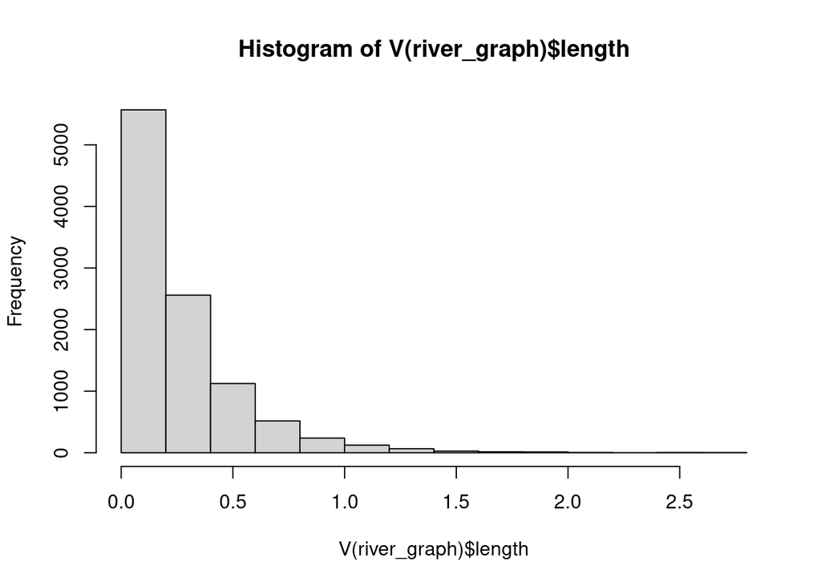

```r
#subset attributes
g2 = river_graph
l = c("MAINDRAIN_ID","LENGTH","CUM_LEN","PIXELS_100M","CATCHMENT_AREA","CONT_PIXELS","DRAIN_KM2","BURNED","CONFIDENCE","WINDOW" , "SHAPE_Length"  )

#remove obsolete attributes
for (i in l){
  g2<-delete_vertex_attr(g2, i)
}

river_graph<-g2


# update length attribute
V(river_graph)$length <- V(river_graph)$length / 10000
hist(V(river_graph)$length)
```

```r
# Function for organism that prefers high elevation
suit_fun_high <- function(x){dnorm(x, mean = 1500, sd = 500)*410*sqrt(3*pi)}
# Function for organism that prefers low elevation
suit_fun_low <- function(x){exp(- 0.001*x)}
# Calculate HSI for the igraph nodes
V(river_graph)$HSI_low <- suit_fun_low(V(river_graph)$alt)
V(river_graph)$HSI_high <- suit_fun_high(V(river_graph)$alt)
# Calculate weighted usable length for igraph nodes
V(river_graph)$WUL_low <- V(river_graph)$HSI_low * V(river_graph)$length
V(river_graph)$WUL_high <- V(river_graph)$HSI_high * V(river_graph)$length
```

Now the indices can be calculated using the function ‘index_calculation’ of the riverconn package.

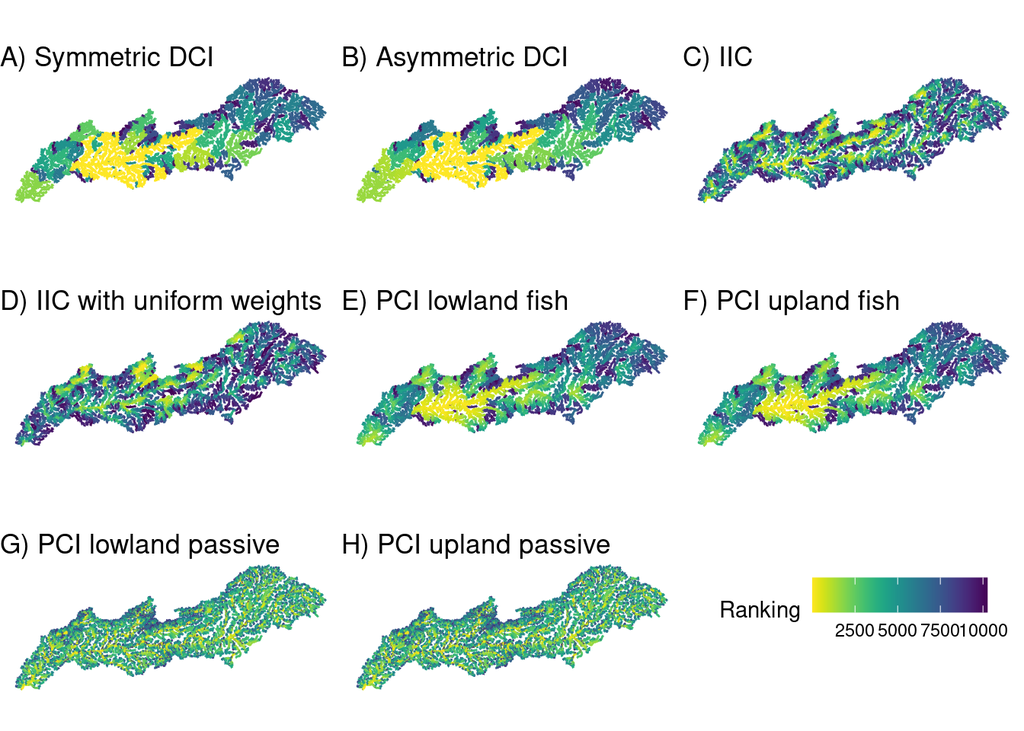

```r
# Initialize list where to store all the index calculation outputs
index <- list()
lab_index <- list()
letter_index <- list()

##Correct graph attributes!
# 1: Symmetric Dendritic Connectivity Index (no biotic effects)
lab_index[[1]] <- "Symmetric DCI"
letter_index[[1]] <- "A"
index[[1]] <- index_calculation(graph = river_graph,
                                weight = "length",
                                B_ij_flag = FALSE,
                                index_type = "reach",
                                index_mode = "from")

# 2: Asymmetric Dendritic Connectivity Index (no biotic effects)
lab_index[[2]] <- "Asymmetric DCI"
letter_index[[2]] <- "B"
index[[2]] <- index_calculation(graph = river_graph,
                                weight = "length",
                                B_ij_flag = FALSE,
                                dir_fragmentation_type = "asymmetric",
                                index_type = "reach",
                                index_mode = "from")

## Before calculating IIC a binary passability has to be defined
E(river_graph)$pass_u_bin <- ifelse(is.na(E(river_graph)$pass_u), NA, 0)
E(river_graph)$pass_d_bin <- ifelse(is.na(E(river_graph)$pass_d), NA, 0)

# 3: Symmetric Integral Index of Connectivity
lab_index[[3]] <- "IIC"
letter_index[[3]] <- "C"
index[[3]] <- index_calculation(graph = river_graph,
                                weight = "length",
                                pass_u = "pass_u_bin",
                                pass_d = "pass_d_bin",
                                param = 3,
                                disp_type = "threshold",
                                index_type = "reach",
                                index_mode = "from")

## Defining uniform weights for IIC
V(river_graph)$unif_w <- 1

# 4: Integral Index of Connectivity with uniform weights
lab_index[[4]] <- "IIC with uniform weights"
letter_index[[4]] <- "D"
index[[4]] <- index_calculation(graph = river_graph,
                                weight = "unif_w",
                                dir_fragmentation_type = "asymmetric",
                                pass_u = "pass_u_bin",
                                pass_d = "pass_d_bin",
                                param = 3,
                                disp_type = "threshold",
                                index_type = "reach",
                                index_mode = "from")

# 5: Population Connectivity Index for lowland fish
lab_index[[5]] <- "PCI lowland fish"
letter_index[[5]] <- "E"
index[[5]] <- index_calculation(graph = river_graph,
                                weight = "WUL_low",   ## weighted usable length
                                param = 0.8,
                                index_type = "reach",
                                index_mode = "from")

# 6: Population Connectivity Index for upland fish
lab_index[[6]] <- "PCI upland fish"
letter_index[[6]] <- "F"
index[[6]] <- index_calculation(graph = river_graph,
                                weight = "WUL_high",
                                param = 0.8,
                                index_type = "reach",
                                index_mode = "from")


# 7: Population Connectivity Index for lowland passive drifter
## note that units of param_d must be consistent with length field (10s of km)
lab_index[[7]] <- "PCI lowland passive"
letter_index[[7]] <- "G"
index[[7]] <- index_calculation(graph = river_graph,
                                weight = "WUL_low",
                                dir_distance_type  = "asymmetric",
                                disp_type = "threshold",
                                param_u = 0,
                                param_d = 3,
                                index_type = "reach",
                                index_mode = "from")

# 8: Population Connectivity Index for upland passive drifter
## note that units of param_d must be consistent with length field (10s of km)
lab_index[[8]] <- "PCI upland passive"
letter_index[[8]] <- "H"
index[[8]] <- index_calculation(graph = river_graph,
                                weight = "WUL_high",
                                dir_distance_type  = "asymmetric",
                                disp_type = "threshold",
                                param_u = 0,
                                param_d = 3,
                                index_type = "reach",
                                index_mode = "from")


# Initialize empty list
plot_list <- list()

# iterate through list length
for (i in 1:length(index)) {

  # Join d_i information with dams shapefile
  river_plot <- river_net_sliced %>%
    mutate(name = as.character(EdgeID)) %>%
    left_join(index[[i]]) %>%
    mutate(rank = rank(desc(index)))

  # plot
  plot_iter <- ggplot() +
    coord_fixed() +
    ggspatial::layer_spatial(river_plot, aes(color = rank))+
    scale_color_viridis(name = "Ranking", direction = -1)+
    theme_void()+
    guides(size = FALSE) +
    theme(legend.position = "bottom")+
    ggtitle(paste0(letter_index[[i]], ") ", lab_index[[i]]))

  legend <- cowplot::get_legend(plot_iter)

  plot_list[[i]] <- plot_iter +
    theme(legend.position = "none")

}

plot_list[[length(index)+1]] <- legend

plot_final <- ggpubr::ggarrange( plotlist = plot_list)
plot_final
```